# Lab 8: Variance of Sample Means and Correlation

## 2. Variability of the Sample Mean

By the Central Limit Theorem, the probability distribution of the mean of a large random sample is roughly normal. The bell curve is centered at the population mean. Some of the sample means are higher, and some lower, but the deviations from the population mean are roughly symmetric on either side, as we have seen repeatedly. Formally, probability theory shows that the sample mean is an unbiased estimate of the population mean.

In our simulations, we also noticed that the means of larger samples tend to be more tightly clustered around the population mean than means of smaller samples. In this section, we will quantify the variability of the sample mean and develop a relation between the variability and the sample size.

Let's take a look at the salaries of employees of the City of San Francisco in 2014. The mean salary reported by the city government was about $75463.92.

```python
salaries = Table.read_table('sf_salaries_2014.csv').select("salary")
salaries
```

| salary |
| --- |
| 471953 |
| 390112 |
| 339654 |
| 326717 |
| 326233 |
| 344187 |
| 311299 |
| 310161 |
| 335485 |
| 329391 |

... (38113 rows omitted)

```python
salary_mean = np.mean(salaries.column('salary'))
salary_mean
```

```
75463.918140230307
```

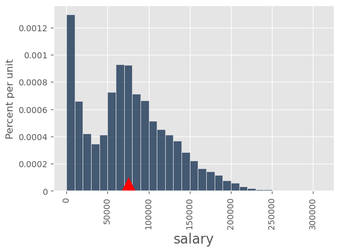

```python
salaries.hist('salary', bins=np.arange(0, 300000+10000*2, 10000))
plt.scatter(salary_mean, 0, marker='^', color='red', s=1000);
```

**Question 8**

Clearly, the population does not follow a normal distribution. Keep that in mind as we progress through these exercises.

Let's take random samples and look at the probability distribution of the sample mean. As usual, we will use simulation to get an empirical approximation to this distribution.

We will define a function `simulate_sample_mean` to do this, because we are going to vary the sample size later. The arguments are the name of the table, the label of the column containing the variable, the sample size, and the number of simulations.

Complete the function `simulate_sample_mean`.

```python
"""Empirical distribution of random sample means"""

def simulate_sample_mean(table, label, sample_size, repetitions):

    means = []

    for i in np.arange(repetitions):
        new_sample = table.sample(sample_size)
        new_sample_mean = np.mean(new_sample.column(label))
        means = np.append(means, new_sample_mean)

    sample_means = Table().with_column('Sample Means', means)

    # Display empirical histogram and print all relevant quantities – don't change this!
    fig, ax = plt.subplots()
    ax.hist(means, bins=20)
    plt.xlabel('Sample Means')
    plt.title('Sample Size ' + str(sample_size))

    textstr = '\n'.join((
    r'$\mathrm{Sample  Size}=%.2f$' % (sample_size, ),
    r'$\mathrm{Population  Mean}=%.2f$' % (np.mean(table.column(label)), ),
    r'$\mathrm{Average Of Sample Means}=%.2f$' % (np.mean(means), ),
    r'$\mathrm{Population SD}=%.2f$' % (np.std(table.column(label)), ),
    r'$\mathrm{SD Of Sample Means}=%.2f$' % (np.std(means), )))

    # these are matplotlib.patch.Patch properties
    props = dict(boxstyle='round', facecolor='wheat', alpha=0.5)

    # place a text box in upper left in axes coords
    ax.text(0.95, 0.75, textstr, transform=ax.transAxes, fontsize=14,
            verticalalignment='top', bbox=props)

    return means
```

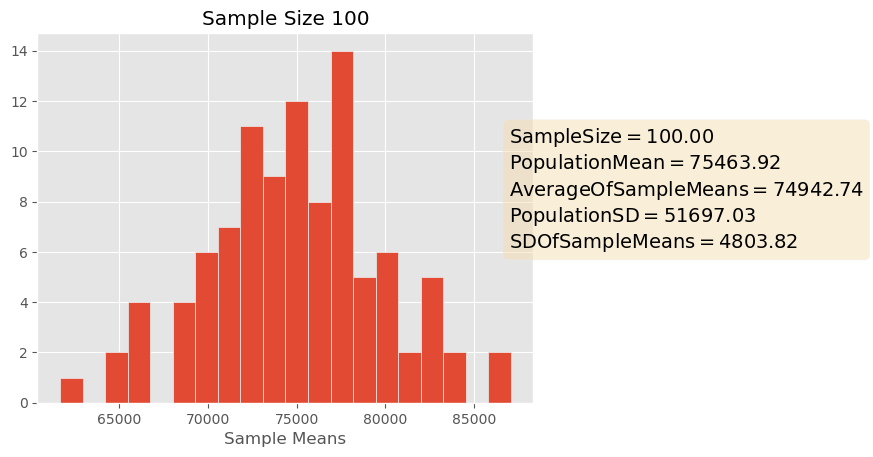

```python
check('tests/q8.py')
```

**Question 9**

In the following cell, we will create a sample of size 100 from the salaries table and graph it using our new `simulate_sample_mean` function.

```
(50000.0, 100000.0)
```

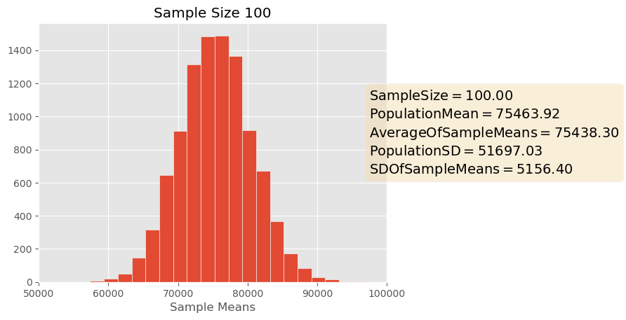

```python
small_sample_size = simulate_sample_mean(salaries, 'salary', 100, 10000)
plt.xlim(50000, 100000)
```

In the following two cells, simulate the mean of a random sample of 400 salaries and 625 salaries, respectively. In each case, perform 10,000 repetitions of each of these processes. Don't worry about the `plots.xlim` line – it just makes sure that all of the plots have the same x-axis.

```
(50000.0, 100000.0)
```

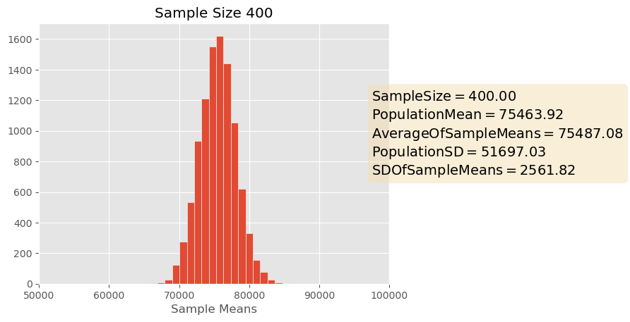

```python
four_hundred_sample_mean= simulate_sample_mean(salaries, 'salary', 400, 10000)
plt.xlim(50000, 100000)
```

```
(50000.0, 100000.0)
```

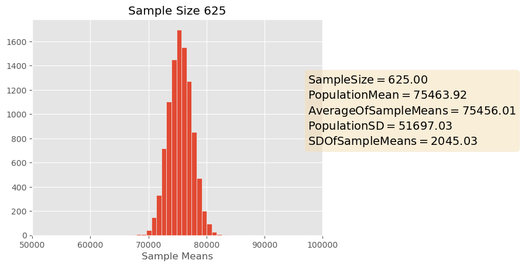

```python
six_hundred_twenty_five_sample_mean= simulate_sample_mean(salaries, 'salary', 625, 10000)
plt.xlim(50000, 100000)
```

We can see the Central Limit Theorem in action – the histograms of the sample means are roughly normal, even though the histogram of the salaries themselves is far from normal.

We can also see that each of the three histograms of the sample means is centered very close to the population mean. In each case, the "average of sample means" is very close to the population mean. Both values are provided in the printout above each histogram. As expected, the sample mean is an unbiased estimate of the population mean.

**Question 10**

Below, we'll look at what happens when we take a fixed sample, then bootstrap from it with different numbers of resamples. How does the distribution of the resampled means change?

```
(50000.0, 100000.0)
```

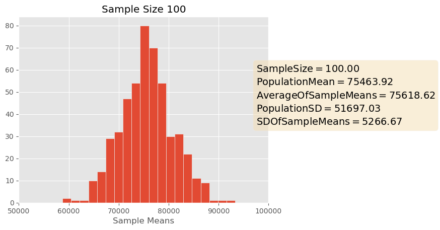

```python
simulate_sample_mean(salaries, 'salary', 100, 500)
plt.xlim(50000, 100000)
```

```
(50000.0, 100000.0)
```

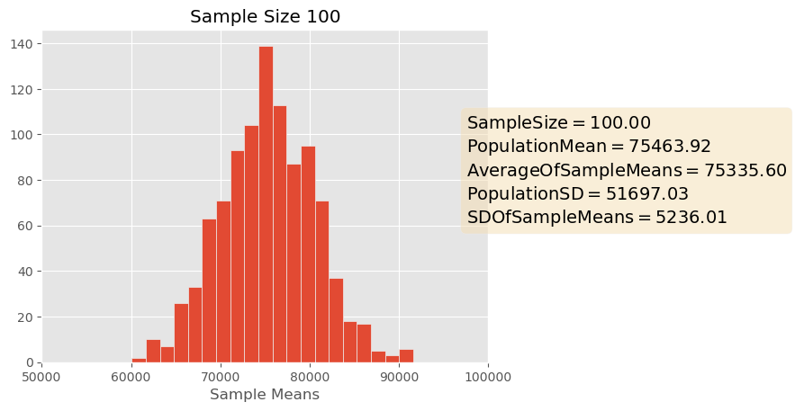

```python
simulate_sample_mean(salaries, 'salary', 100, 1000)
plt.xlim(50000, 100000)
```

```
(50000.0, 100000.0)
```

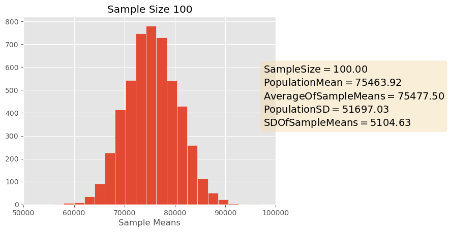

```python
simulate_sample_mean(salaries, 'salary', 100, 5000)
plt.xlim(50000, 100000)
```

```
(50000.0, 100000.0)
```

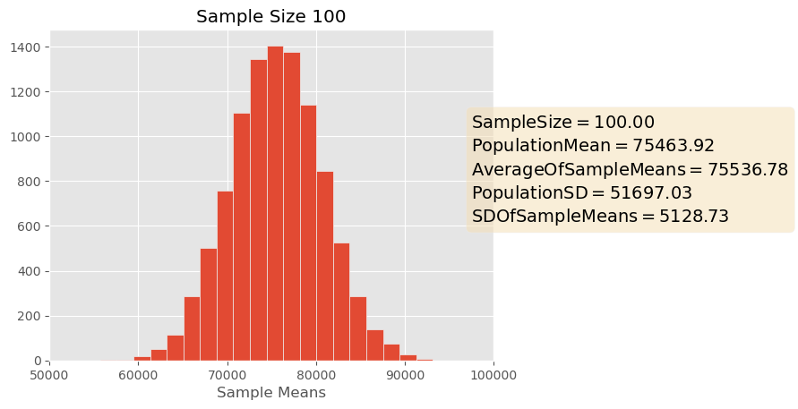

```python
simulate_sample_mean(salaries, 'salary', 100, 10000)
plt.xlim(50000, 100000)
```

Assign the variable `bootstrap_sampled_SD` to the integer corresponding to your answer to the following prediction question:

When I increase the number of bootstrap samples that I take, for a fixed sample size, the SD of my sample mean will...

1. Increase
2. Decrease
3. Stay about the same
4. Vary widly

```python
bootstrap_sampled_SD = 3
```

```python
check('tests/q10.py')
```

All tests passed!

What did you notice about the sample means of the four bootstrapped samples above? I noticed that the sample size remained the same and the standard deviation remains the same. However, the graphs show that the sample size means becomes slightly thinner and slightly varies depending the average sample size means.

**Question 11**

Next, let's think about how the relationships between population SD, sample SD, and SD of sample means change with varying sample size. Which of the following is true? Again, assign the variable `pop_vs_sample` to the integer corresponding to your answer. To gain some intuition, you can run the simulation cells below.

1. Sample SD gets smaller with increasing sample size, SD of sample means gets smaller with increasing sample size
2. Sample SD gets larger with increasing sample size, SD of sample means stays the same with increasing sample size
3. Sample SD becomes more consistent with population SD with increasing sample size, SD of sample means gets smaller with increasing sample size
4. Sample SD becomes more consistent with populatoin SD with increasing sample size, SD of smaple means stays the same with increasing sample size

```python
pop_vs_sample = 3
```

```python
check('tests/q11.py')
```

All tests passed!

Let's see what happens: First, we calculate the population SD so that we can compare the SD of each sample to the SD of the population.

```python
pop_sd = np.std(salaries.column("salary"))
pop_sd
```

```
51697.034986465304
```

Let's then how a small sample behaves. Run the following cells multiple times to see how the SD of the sample changes from sample to sample. Adjust the bins as necessary.

```
Sample SD:  56755.3898151
```

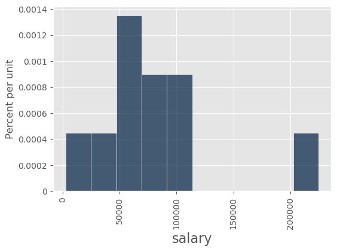

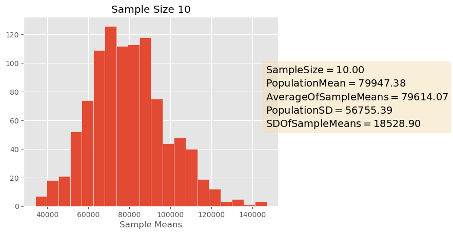

```python
sample_10 = salaries.sample(10)
sample_10.hist("salary")
print("Sample SD: ", np.std(sample_10.column("salary")))
means = simulate_sample_mean(sample_10, 'salary', 10, 1000)
```

```
Sample SD:  48532.5979347
```

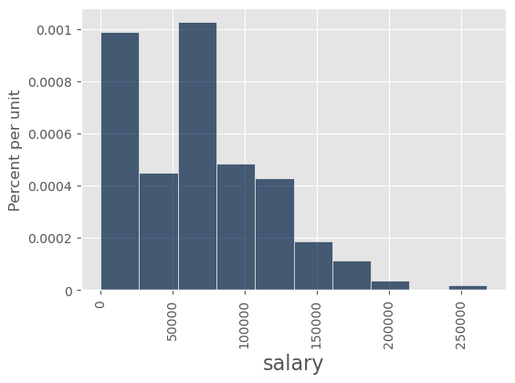

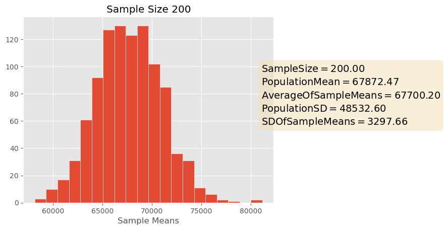

```python
sample_200 = salaries.sample(200)
sample_200.hist("salary")
print("Sample SD: ", np.std(sample_200.column("salary")))
means = simulate_sample_mean(sample_200, 'salary', 200, 1000)
```

```
Sample SD:  48609.7475656
```

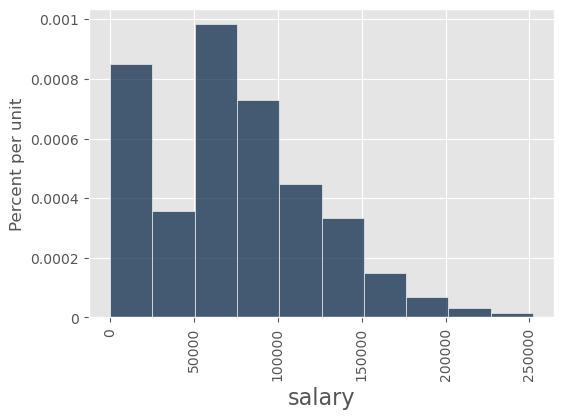

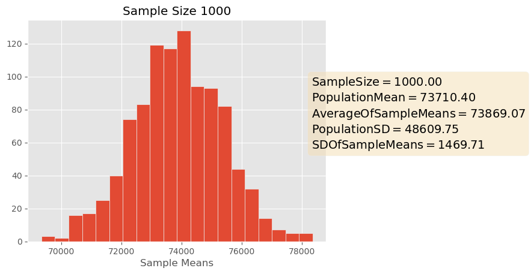

```python
sample_1000 = salaries.sample(1000)
sample_1000.hist("salary")
print("Sample SD: ", np.std(sample_1000.column("salary")))
means = simulate_sample_mean(sample_1000, 'salary', 1000, 1000)
```

Let's illustrate this trend. Below, you will see how the average absolute error of SD from the population changes with sample size (N).

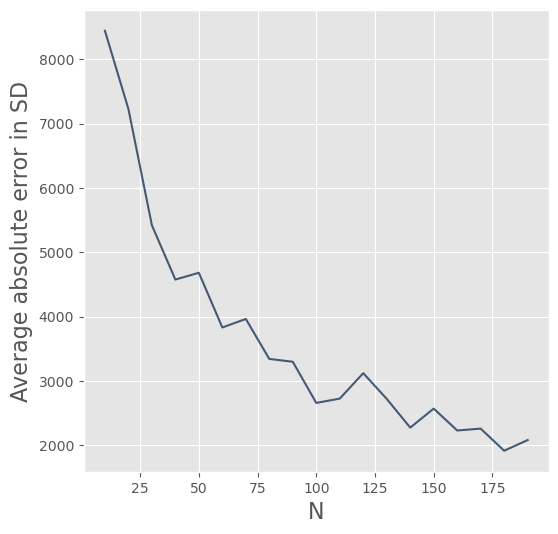

```python
# Don't change this cell, just run it!
sample_n_errors = make_array()
for i in np.arange(10, 200, 10):
    sample_n_errors = np.append(sample_n_errors, np.average([abs(np.std(salaries.sample(i).column("salary"))-pop_sd)
                                                             for d in np.arange(100)]))
Table().with_columns("Average absolute error in SD", sample_n_errors, "N", np.arange(10, 200, 10)).plot("N", "Average absolute error in SD")
```

You should notice that the distribution of means gets spiker, and that the distribution of the sample increasingly looks like the distribution of the population as we get to larger sample sizes.

Is there a relationship between the sample size and absolute error in standard deviation? Identify this relationship – if you're having trouble, take a look at this [section](https://inferentialthinking.com/chapters/14/5/Variability_of_the_Sample_Mean.html) in our textbook about the variability of sample means.

## Submission

You're finished with lab 8! In order to successfully submit your assignment, follow these steps...

- **IMPORTANT** Before you do anything, **Save and Checkpoint** from the `File` menu. Please do this first before running the cell below,
- **run all the tests and verify that they all pass** (the next cell has a shortcut for that),
- **Review the notebook one last time** If you make any changes, please **Save and Checkpoint** again.
- Download as an .html file and/or an .ipynb file and submit on Canvas!

```
Testing question 1:
Passed
Testing question 3:
Passed
Testing question 5:
Passed
Testing question 6:
Passed
Testing question 7:
Passed
Testing question 8:
Passed
Testing question 10:
Passed
Testing question 11:
Passed
Grade:  1.0
```

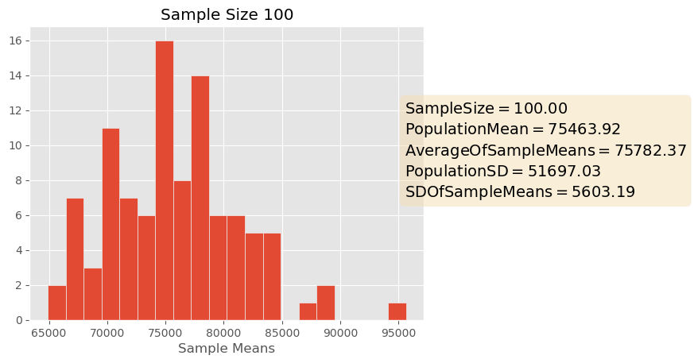

```python
# For your convenience, you can run this cell to run all the tests at once!
import glob
from gofer.ok import check
correct = 0
checks = [1,3,5,6,7,8,10,11]
total = len(checks)
for x in checks:
    print('Testing question {}: '.format(str(x)))
    g = check('tests/q{}.py'.format(str(x)))
    if g.grade == 1.0:
        print("Passed")
        correct += 1
    else:
        print('Failed')
        display(g)

print('Grade:  {}'.format(str(correct/total)))
```